# Texas ISD Lead Scoring Report

# Executive Summary

This report identifies Texas school districts with the strongest combination of scale, federal funding support, and student need, with the goal of improving territory prioritization and call preparation.

Key takeaways:

- High-opportunity districts are concentrated in a limited number of geographic clusters rather than evenly distributed statewide.
- The strongest targets combine large enrollment with above-average Title I funding per student.
- District-level context varies meaningfully, making tailored outreach more effective than one-size-fits-all messaging.

# Top Opportunities in Texas

**How to use this section**

Start with the table to identify a shortlist of high-priority districts, then use the map to spot geographic clusters and plan efficient coverage.  
*(Deep Dive tools will be added next for meeting and outreach preparation.)*

## Top Districts (Interactive Table)

The table below ranks districts by our custom Lead Score and includes key context metrics used for outreach planning. Use the search bar and column filters to narrow to your target set (for example: focus on specific regions or the largest enrollment bands).

**A quick note on our Lead Score methodology**

What it is: A composite prioritization score to rank Texas ISDs by opportunity based on scale, funding, and student/community need.

How it’s calculated: weighted average of percentile ranks across 4 inputs:

- Enrollment (30%)
- Title I allocations per student (30%)
- Student economic disadvantage rate (20%)
- Child poverty rate (20%)

Lead Tiers (for planning):

- A-tier: top 15% by Lead Score
- B-tier: 50th–85th percentile
- C-tier: bottom 50%

**Other Variables Available**

| Variable | Category | How it can be used |
| --- | --- | --- |
| Number of Schools | District scale and structure | Total campuses; useful for estimating footprint and implementation complexity. |
| Average School Enrollment | District scale and structure | Average size per campus; helps distinguish many small schools vs fewer large schools. |
| Total Population | Demographics and growth context | Community scale proxy; can indicate broader market size and local ecosystem. |
| Population Growth | Demographics and growth context | Momentum indicator; highlights expanding areas and potential enrollment tailwinds. |
| Median Age | Demographics and growth context | Family life-cycle context; can correlate with school-age population dynamics. |
| Median Income | Socioeconomic context | Affluence context; helps tailor messaging and understand resource constraints. |
| Adult Higher Education Rate | Socioeconomic context | Education attainment; can correlate with engagement patterns and program priorities. |
| Hispanic Share of Population | Community composition | Demographic context; supports culturally relevant outreach and program alignment. |
| Racial Diversity | Community composition | Diversity context; supports inclusive positioning and market segmentation. |

|  | District | Region | Score | Enrollment | Schools | Title I $ / Student | Econ Disadv % | Child Poverty % | Growth |
| --- | --- | --- | --- | --- | --- | --- | --- | --- | --- |
| 1 | DONNA ISD | 01 | 96.59187493960253 | 12937 | 19 | 1487.45 | 0.9235 | 0.510496294284273 | ↗ Moderate growth |
| 2 | SAN ANTONIO ISD | 20 | 96.5500967483128 | 44047 | 85 | 893.53 | 0.8690000000000001 | 0.4132891770011274 | — Stable |
| 3 | LA JOYA ISD | 01 | 96.43465050374296 | 22942 | 36 | 1001.82 | 0.9226000000000001 | 0.4193947058316328 | — Stable |
| 4 | LAREDO ISD | 01 | 96.05264636412873 | 20271 | 30 | 789.36 | 0.9712999999999999 | 0.4384655721834537 | ↓ Declining |
| 5 | ALDINE ISD | 04 | 95.87045389678832 | 56419 | 75 | 828.57 | 0.8681 | 0.3592150352255071 | ↗ Moderate growth |
| 6 | BROWNSVILLE ISD | 01 | 95.8623634455434 | 36140 | 53 | 853.76 | 0.8928999999999999 | 0.3636314693848252 | — Stable |
| 7 | ALIEF ISD | 04 | 95.28555921873209 | 38610 | 47 | 944.56 | 0.8632 | 0.3468282696415856 | — Stable |
| 8 | PHARR-SAN JUAN-ALAMO ISD | 01 | 94.81514442579146 | 29613 | 45 | 677.29 | 0.9405 | 0.368556523337853 | ↗ Moderate growth |
| 9 | EDGEWOOD ISD | 20 | 94.69336066107975 | 7849 | 22 | 1162.15 | 0.9369 | 0.4869242549181294 | — Stable |
| 10 | EDINBURG CISD | 01 | 94.62629980964967 | 33343 | 47 | 849.91 | 0.807 | 0.3900473166255869 | ↗ Moderate growth |

[output cut: 1000 more lines]

## Geographic Clusters of Opportunity

This map shows every Texas ISD colored by Lead Tier, so you can quickly spot pockets of high-priority outreach. Use it to plan efficient coverage, grouping nearby top districts into the same trip or campaign. Lead Tiers are percentile-based: A = top 15%, B = 50–85%, C = bottom 50% of districts by Lead Score.

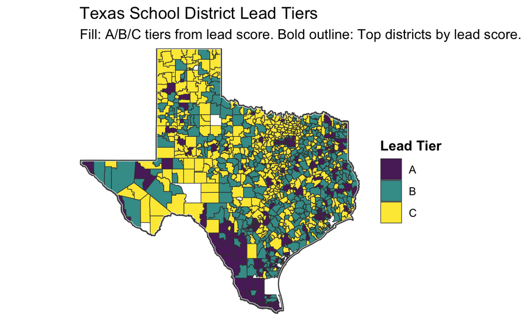